# How can a fitness technology company play it smart?

Senura Charith Attanayake

2024-05-22

# Business Task

Bellabeat, a high-tech manufacturer of health-focused products for women, wants to unlock new growth opportunities by analyzing smart device data. The key business task is to analyze usage patterns from non-Bellabeat smart devices, derive insights on consumer behavior, and apply these findings to improve Bellabeat’s products. The goal is to inform Bellabeat’s marketing strategy with data-driven insights and provide high-level recommendations to the executive team on how to optimize their product offerings and market positioning.

#### Key questions driving the analysis:

1. What are the emerging trends in smart device usage?
2. How can these trends be applied to Bellabeat’s customer base?
3. What marketing strategies can be recommended based on these trends to increase Bellabeat’s market presence?

# The Data

### Data sources:

Fitbit Fitness Tracker Data: A [dataset from Kaggle](https://www.kaggle.com/datasets/arashnic/fitbit) containing detailed information on physical activity, heart rate, and sleep patterns.

### Data Structure:

The dataset allows for detailed exploration of physical activity, sleep patterns, and heart rate, providing rich insights into how users interact with their devices and health data.

### Limitations:

**For certain dataset only about 8 participants provided comprehensive details, This is not enough to get a thorough idea about user behavior**

# Data preprocessing

In this preprocessing step, we perform multiple actions to clean and prepare the Fitbit dataset for analysis. Here’s a breakdown of what happens during this stage:

### Library Loading:

The tidyverse library is loaded, which includes essential packages for data manipulation, such as ggplot2, dplyr, and readr.

### Data Loading:

Various Fitbit CSV datasets are imported using read_csv(). Each dataset contains different information related to users’ daily activities, heart rates, sleep patterns, etc. These datasets are assigned to variables like dailyActivity, dailyCalories, and heartRateSeconds, allowing us to work with them in subsequent analysis steps. Missing Value Detection:

- The code then checks for missing values across all the imported datasets * using colSums(is.na()). This step helps in identifying any gaps in the data, which is critical for maintaining data quality in the analysis. In particular, the weightLogInfo dataset has missing values in the “Fat” column, which are addressed by removing the entire column using select(-Fat). Exploratory Data Summarization:

The skimr and janitor packages are used to generate a clean summary of the datasets. Functions like skim_without_charts() and summary() provide essential information such as the data’s distribution, mean, and other statistical details for each column. This ensures that we have a solid understanding of the structure and content of the datasets before diving into deeper analysis. ### Summary Statistics:

Summary statistics are printed for each dataset, providing a quick snapshot of key metrics such as the number of entries, minimum, maximum, and average values for numeric fields. This helps identify patterns and potential anomalies in the data. Date and Time Handling:

The lubridate package is used to handle date-time formats. For example, the Time column in heartRateSeconds is converted to a POSIXct format to facilitate time-based analysis, enabling accurate plotting of heart rate over time.

### Data Transformation:

The mutate() function from dplyr is used to calculate new columns based on existing data. For example, in dailyActivity, the total active minutes are calculated, and activity levels are converted into percentages. This transformation makes it easier to interpret how users spend their time (e.g., sedentary vs. very active). Data Cleaning:

- Cleaning actions include removing unnecessary columns (like the “Fat” column from weightLogInfo) and correcting data types (such as converting date columns to proper date formats). These steps ensure that the data is ready for effective analysis without errors or inconsistencies.*

# Analysis

This analysis aims to explore and visualize various aspects of Fitbit data, including daily activities, heart rates, sleep patterns, and weight logs. The goal is to derive meaningful insights that can help users understand their health and activity levels.

### We start by importing the Libraries

```r
# Load Required Packages
install.packages("tidyverse")
library(tidyverse)
install.packages("here")
library(here)
install.packages("skimr")
library(skimr)
install.packages("janitor")
library(janitor)
```

### Check for missing values in each dataset

```r
# Check for missing values
missing_values <- lapply(list(dailyActivity, dailyCalories, dailyIntensities, dailySteps,
                               heartRateSeconds, hourlyCalories, hourlyIntensities,
                               hourlySteps, minuteCaloriesNarrow, minuteCaloriesWide,
                               minuteIntensitiesNarrow, minuteIntensitiesWide,
                               minuteMETsNarrow, minuteSleep, minuteStepsNarrow,
                               minuteStepsWide, sleepDaily, weightLogInfo),
                         function(x) colSums(is.na(x)))
```

### We look at the summary statistics for each dataset

```r
# Check for missing values
# Summary statistics for all datasets
lapply(list(dailyActivity, dailyCalories, dailyIntensities, dailySteps,
            heartRateSeconds, hourlyCalories, hourlyIntensities,
            hourlySteps, minuteCaloriesNarrow, minuteCaloriesWide,
            minuteIntensitiesNarrow, minuteIntensitiesWide,
            minuteMETsNarrow, minuteSleep, minuteStepsNarrow,
            minuteStepsWide, sleepDaily, weightLogInfo), summary)
```

[output not shown]

## Daily Activity Analysis

### Average Calories Burned

We calculate the average calories burned per user and visualize the results.

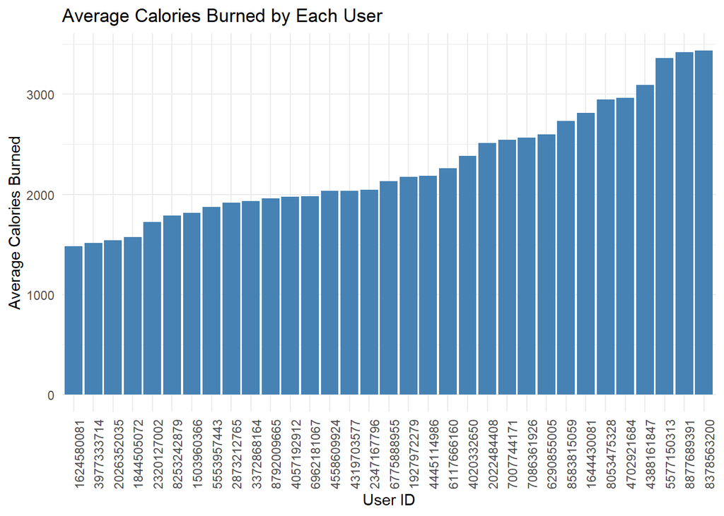

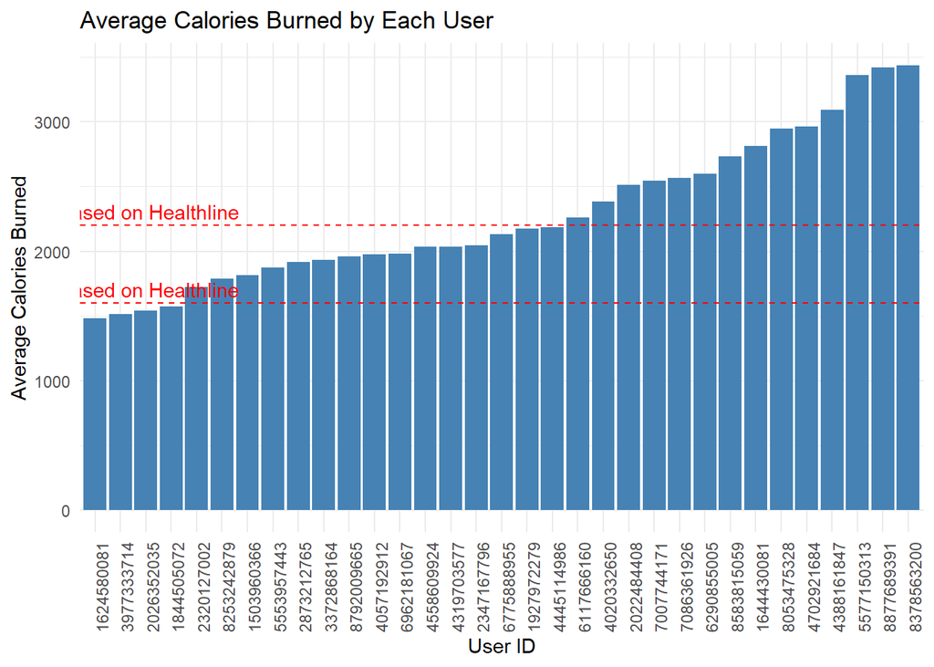

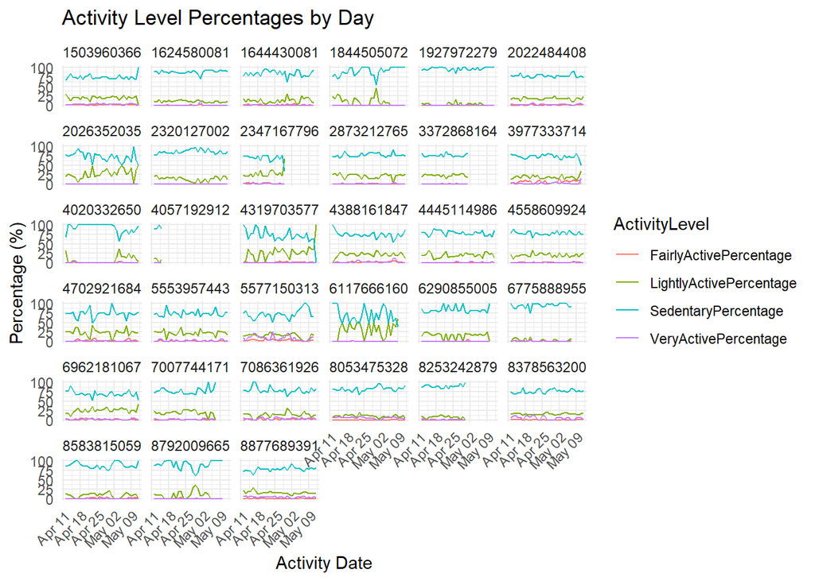

## Weight Log Analysis

### BMI Calculation

We compute BMI categories based on the earliest records.

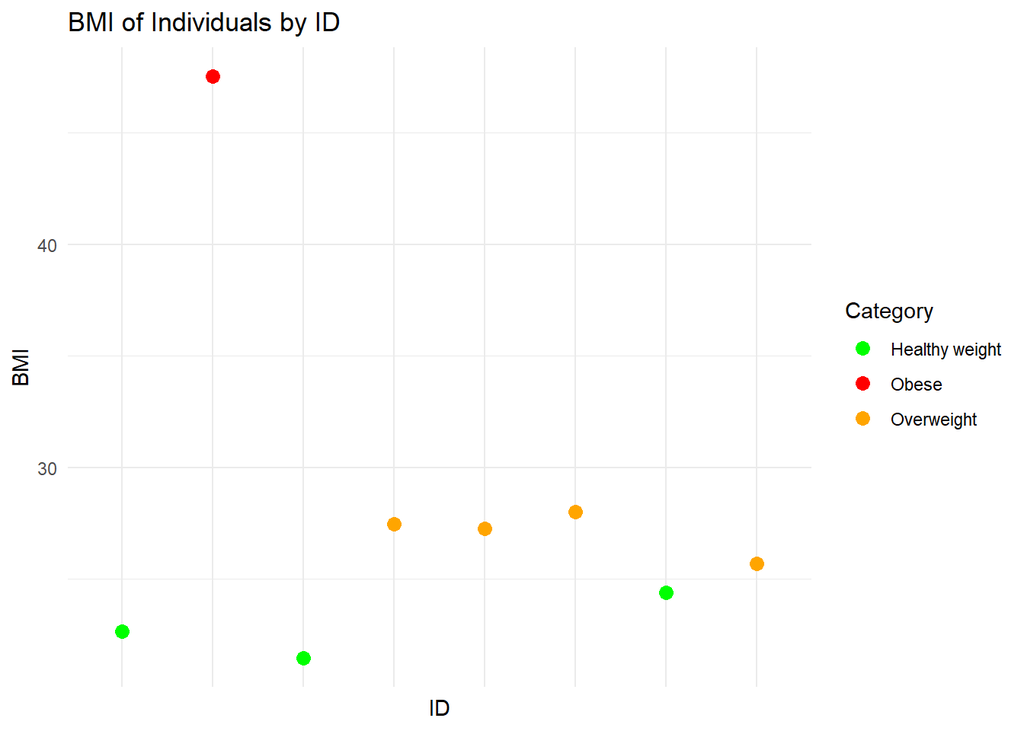

## Heart Rate Analysis

### Mean and Variance of Heart Rate

We analyze heart rate data, focusing on the mean and variance.

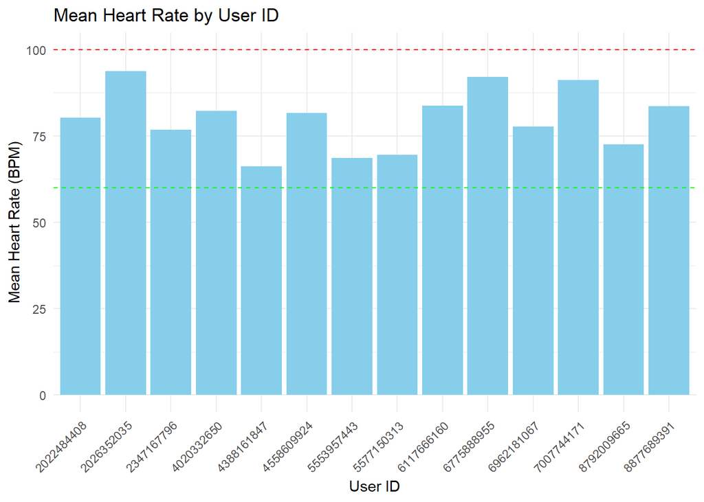

### Variance of Heart Rate

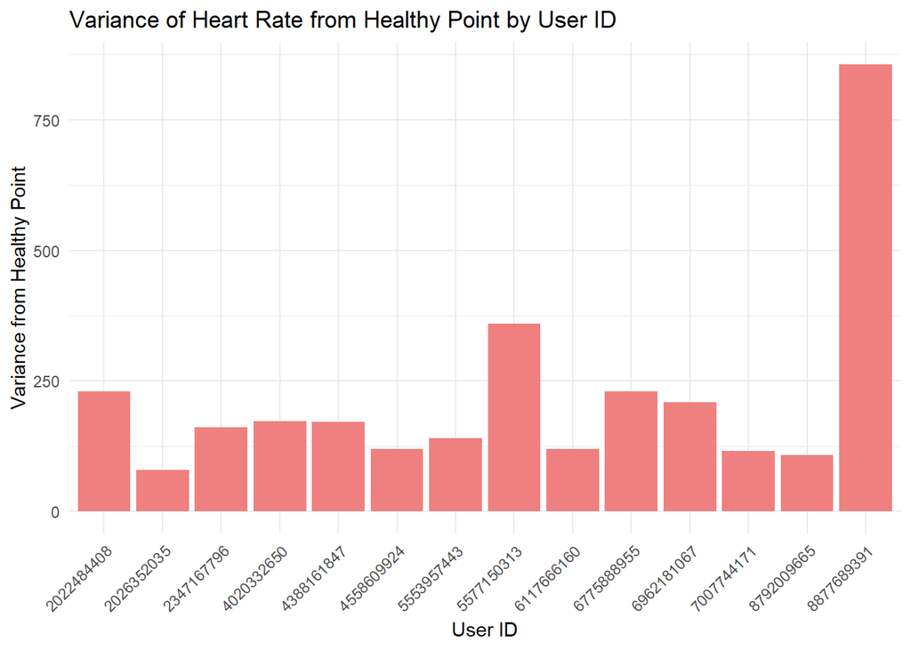

## Sleep Analysis

### Sleep Patterns

We evaluate the total time in bed versus the time spent sleeping.

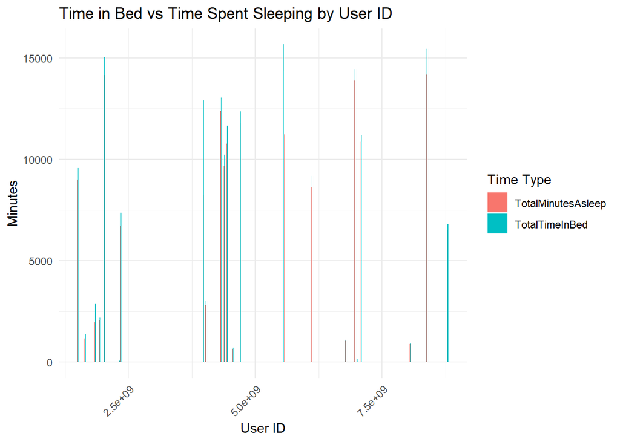

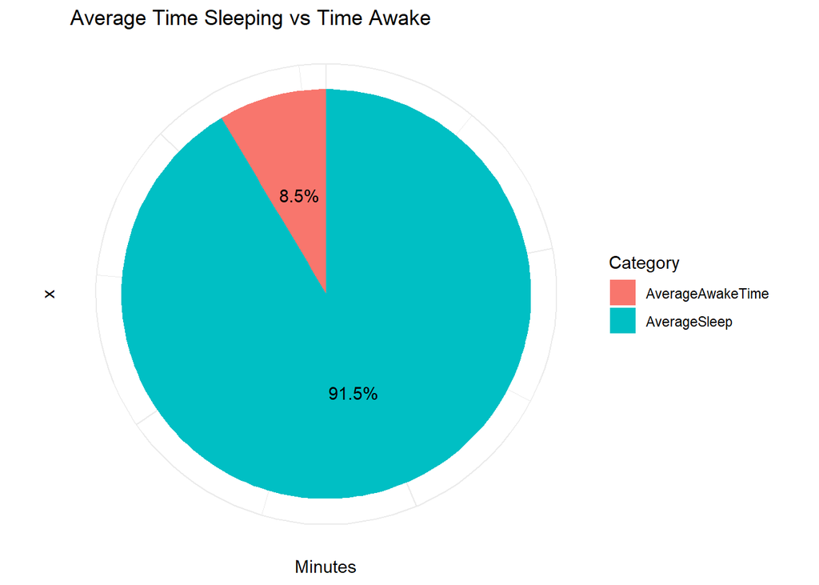

# Summary of Analysis

## Conclusion

*The provided dataset is not enough for a complete analysis.

*The mean heartrates for the Users indicate that the assessed user group has healthy heartrates. All of the users have heartrates within the healthy limit (60 - 100).

*The heartrate variance chart shows that 1/14 individuals display a significant variance from an accepted healthy heartrate of 80 BPM.

*The sleep partterns chart indicates that most participants spend minimal awake minutes in bed. And some users display comparatively larger awake minutes in bed. This can be an indicator of participants having trouble falling asleep or participants staying in bed for long before getting off the bed. The analysis found that the average time spent awake in bed was 8.5%. Although this is a small number, When comparing with sleep hours this is significant and features to help minimize this percentage would benefit.

# Recommendations based on the Analysis

## Future Recommendations

*In conclusion, this comprehensive analysis of Fitbit data offers valuable insights into user behavior, ranging from daily activity patterns to heart rate variability and sleep quality. By carefully preprocessing, cleaning, and analyzing the data, we are better equipped to inform Bellabeat’s marketing strategy and product development. The insights derived from this study have the potential to guide future innovations and enhance user engagement with Bellabeat’s health-focused products. Thank you for following along on this data journey, and I look forward to exploring further opportunities for growth and optimization.*

**Senura Charith Attanayake**